# Universal Differential Equations

A **Universal Differential Equation (UDE)** combines a mechanistic ODE with a neural network to learn unknown or partially-known dynamics from data. The ODE encodes prior biological knowledge; the neural network (called the NDE component) learns residual dynamics the ODE cannot explain on its own.

This notebook demonstrates UDE training on a Lotka-Volterra predator-prey system with an unknown external forcing term.

```python
import diffrax
import jax
import jax.numpy as jnp
import matplotlib.pyplot as plt
import optax
import pandas as pd

from example_models import get_lotka_volterra
from mxlpy import plot
from mxlpy.jax.models import (
    Anode,
    AugUde,
    FluxAnode,
    FluxAugUde,
    FluxOde,
    HardLatentMapper,
    Node,
    Ode,
    Ude,
)
from mxlpy.jax.train import IntegrationSettings, train
```

import diffrax import jax import jax.numpy as jnp import matplotlib.pyplot as plt import optax import pandas as pd from example_models import get_lotka_volterra from mxlpy import plot from mxlpy.jax.models import ( Anode, AugUde, FluxAnode, FluxAugUde, FluxOde, HardLatentMapper, Node, Ode, Ude, ) from mxlpy.jax.train import IntegrationSettings, train

```python
lv = Ode.from_mxlpy(get_lotka_volterra())
ts = jnp.linspace(0, 50, 100)
y0 = jnp.array([10.0, 10.0])
ys = lv.integrate(ts, y0, max_steps=8192)

fig, ax = plt.subplots()
ax.plot(ts, ys)
ax.legend(["prey", "pred"])
plt.show()
```

lv = Ode.from_mxlpy(get_lotka_volterra()) ts = jnp.linspace(0, 50, 100) y0 = jnp.array([10.0, 10.0]) ys = lv.integrate(ts, y0, max_steps=8192) fig, ax = plt.subplots() ax.plot(ts, ys) ax.legend(["prey", "pred"]) plt.show()

[output not shown]

[output not shown]

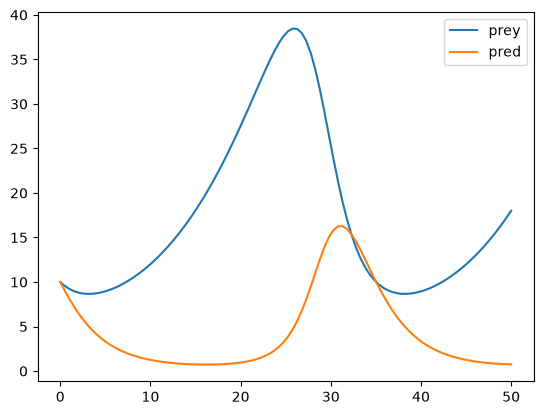

## Baseline: mechanistic ODE

The Lotka-Volterra system describes predator-prey dynamics with four parameters (`a`, `b`, `c`, `d`). This serves as the mechanistic prior — the part of the system we already understand and can encode explicitly.

```python
ys_forced = (ys.T + 0.14 * jnp.sin(ts)).T

fig, ax = plt.subplots()
ax.plot(ts, ys_forced)
ax.legend(["prey", "pred"])
plt.show()
```

ys_forced = (ys.T + 0.14 * jnp.sin(ts)).T fig, ax = plt.subplots() ax.plot(ts, ys_forced) ax.legend(["prey", "pred"]) plt.show()

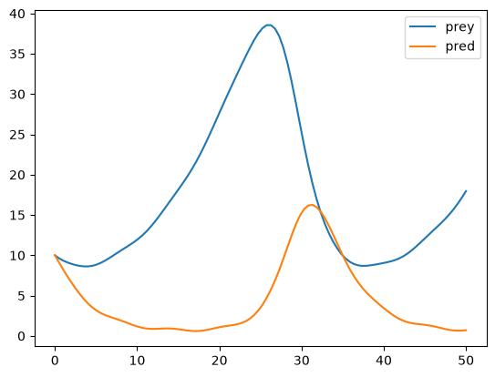

## Training the UDE

We construct a `Ude` by combining the mechanistic `Ode` with a small neural network (`Node`). The `op="+"` means the NDE output is **added** to the ODE right-hand side at each time step.

Training uses `train`, which freezes the ODE parameters and only optimises the neural network weights. A curriculum schedule gradually increases the proportion of the trajectory used for loss computation, which helps avoid poor local minima early in training.

```python
ude, losses, grad_norms = train(
    Ude(
        ode=lv,
        nn=Node(
            variable_names=lv.variable_names,
            width=8,
            depth=3,
            key=jax.random.PRNGKey(42),
            out_scale=jnp.array([0.1]),
        ),
        op="+",
    ),
    ts=ts,
    ys=ys_forced,
    training_steps=[
        (500, 0.2),
        (500, 0.5),
        (10_000, 1.0),  # in practice longer, shortened for docs
    ],
    avg_every=50,
    integration_settings=IntegrationSettings(
        max_steps=8192,
        method=diffrax.Tsit5,
    ),
    optim=optax.adabelief(learning_rate=2e-4),
)

ys_pred = ude.integrate(ts, y0, max_steps=8192)

fig, (ax1, ax2) = plt.subplots(1, 2, figsize=(10, 4), layout="constrained")
# ax1
ax1.plot(ts, ys_forced)
plot.reset_prop_cycle(ax=ax1)
ax1.plot(ts, ys_pred, ls="dashed")
ax1.legend(["prey", "pred"])

# ax2
pd.concat(losses, ignore_index=True)[12:].plot(ax=ax2)
plt.show()
```

ude, losses, grad_norms = train( Ude( ode=lv, nn=Node( variable_names=lv.variable_names, width=8, depth=3, key=jax.random.PRNGKey(42), out_scale=jnp.array([0.1]), ), op="+", ), ts=ts, ys=ys_forced, training_steps=[ (500, 0.2), (500, 0.5), (10_000, 1.0), # in practice longer, shortened for docs ], avg_every=50, integration_settings=IntegrationSettings( max_steps=8192, method=diffrax.Tsit5, ), optim=optax.adabelief(learning_rate=2e-4), ) ys_pred = ude.integrate(ts, y0, max_steps=8192) fig, (ax1, ax2) = plt.subplots(1, 2, figsize=(10, 4), layout="constrained") # ax1 ax1.plot(ts, ys_forced) plot.reset_prop_cycle(ax=ax1) ax1.plot(ts, ys_pred, ls="dashed") ax1.legend(["prey", "pred"]) # ax2 pd.concat(losses, ignore_index=True)[12:].plot(ax=ax2) plt.show()

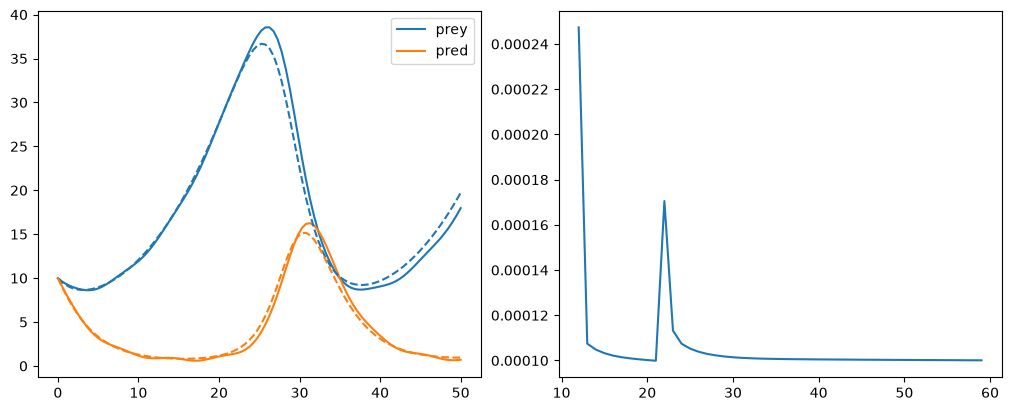

`simulate_time_course` returns the same trajectory as a named result: arrays (`ys`, `readouts`) that also work inside `jax.grad`, and DataFrames for inspection.

```python
sim = ude.simulate_time_course(ts, y0, max_steps=8192)
sim.get_combined().head()
```

sim = ude.simulate_time_course(ts, y0, max_steps=8192) sim.get_combined().head()

|  | Prey | Predator | prey_growth | predation | predator_death |
| --- | --- | --- | --- | --- | --- |
| 0.000000 | 10.000000 | 10.000000 | 1.000000 | 100.000000 | 4.000000 |
| 0.505050 | 9.550497 | 9.020996 | 0.955050 | 86.154999 | 3.608398 |
| 1.010101 | 9.210165 | 8.105617 | 0.921017 | 74.654068 | 3.242247 |
| 1.515152 | 8.962444 | 7.261774 | 0.896244 | 65.083244 | 2.904710 |
| 2.020202 | 8.793915 | 6.492414 | 0.879391 | 57.093735 | 2.596966 |

## Separate the contribution of each model part

After training we can evaluate the ODE and NDE components independently along the predicted trajectory. `jax.vmap` maps each component over all time points in one call. This decomposition reveals what the neural network actually learned — ideally it should recover the unknown forcing signal.

```python
rhs_ode = jax.vmap(ude.ode, in_axes=(0, 0, None))(ts, ys_pred, jnp.array([]))
rhs_nde = jax.vmap(ude.nn, in_axes=(0, 0, None))(ts, ys_pred, jnp.array([]))

fig, (ax1, ax2) = plt.subplots(1, 2, figsize=(10, 4), layout="constrained")
ax1.set(title="ODE")
ax2.set(title="NDE")
ax1.plot(ts, rhs_ode)
ax2.plot(ts, rhs_nde)

for ax in (ax1, ax2):
    ax.legend(["dpreydt", "dpreddt"])
```

rhs_ode = jax.vmap(ude.ode, in_axes=(0, 0, None))(ts, ys_pred, jnp.array([])) rhs_nde = jax.vmap(ude.nn, in_axes=(0, 0, None))(ts, ys_pred, jnp.array([])) fig, (ax1, ax2) = plt.subplots(1, 2, figsize=(10, 4), layout="constrained") ax1.set(title="ODE") ax2.set(title="NDE") ax1.plot(ts, rhs_ode) ax2.plot(ts, rhs_nde) for ax in (ax1, ax2): ax.legend(["dpreydt", "dpreddt"])

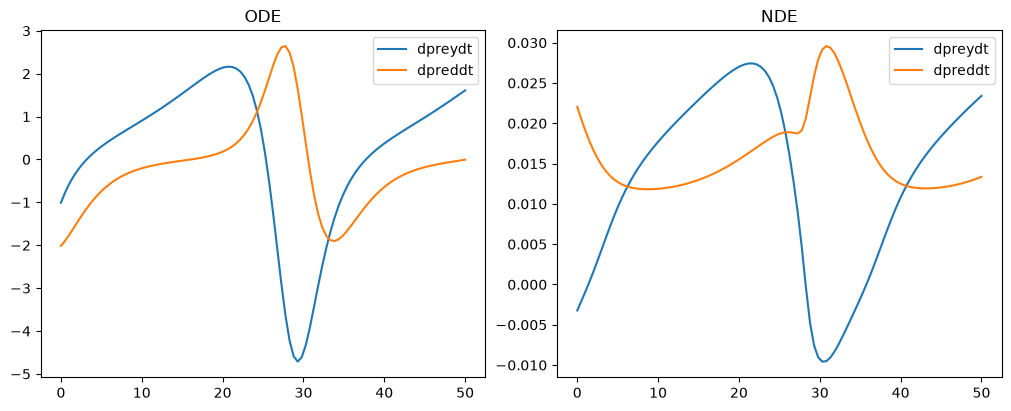

The **ODE** panel shows the mechanistic dynamics encoded in the prior model. The **NDE** panel shows the learned correction — the neural network's contribution that accounts for dynamics the ODE could not explain. A well-trained UDE produces an NDE signal that approximates the unknown forcing term.

## Neural ODEs without a prior: `Node`

`Node` is the neural component on its own, without any mechanistic prior:

\[\frac{dy}{dt} = s \cdot \text{MLP}(y, \text{args})\]

where \(s\) is `out_scale`. We train it on the same data, with the same budget and solver settings as the UDE above. To compare the models fairly, the remaining sections share one helper.

```python
def fit(model):
    trained, losses, _ = train(
        model,
        ts=ts,
        ys=ys_forced,
        training_steps=[
            (500, 0.2),
            (500, 0.5),
            (10_000, 1.0),  # in practice longer, shortened for docs
        ],
        avg_every=50,
        integration_settings=IntegrationSettings(
            max_steps=8192,
            method=diffrax.Tsit5,
        ),
        optim=optax.adabelief(learning_rate=2e-4),
    )
    return trained, pd.concat(losses, ignore_index=True)


def plot_fit(model, losses):
    ys_pred = model.integrate(ts, y0, max_steps=8192)
    fig, (ax1, ax2) = plt.subplots(1, 2, figsize=(10, 4), layout="constrained")
    ax1.plot(ts, ys_forced)
    plot.reset_prop_cycle(ax=ax1)
    ax1.plot(ts, ys_pred, ls="dashed")
    ax1.legend(["prey", "pred"])
    losses[12:].plot(ax=ax2)
    plt.show()


node, node_losses = fit(
    Node(
        variable_names=lv.variable_names,
        width=8,
        depth=3,
        key=jax.random.PRNGKey(42),
    )
)
plot_fit(node, node_losses)
```

def fit(model): trained, losses, _ = train( model, ts=ts, ys=ys_forced, training_steps=[ (500, 0.2), (500, 0.5), (10_000, 1.0), # in practice longer, shortened for docs ], avg_every=50, integration_settings=IntegrationSettings( max_steps=8192, method=diffrax.Tsit5, ), optim=optax.adabelief(learning_rate=2e-4), ) return trained, pd.concat(losses, ignore_index=True) def plot_fit(model, losses): ys_pred = model.integrate(ts, y0, max_steps=8192) fig, (ax1, ax2) = plt.subplots(1, 2, figsize=(10, 4), layout="constrained") ax1.plot(ts, ys_forced) plot.reset_prop_cycle(ax=ax1) ax1.plot(ts, ys_pred, ls="dashed") ax1.legend(["prey", "pred"]) losses[12:].plot(ax=ax2) plt.show() node, node_losses = fit( Node( variable_names=lv.variable_names, width=8, depth=3, key=jax.random.PRNGKey(42), ) ) plot_fit(node, node_losses)

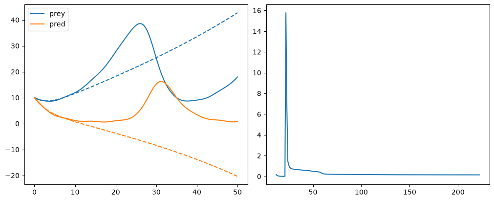

The pure neural ODE settles into a poor solution: it follows the first few time points, then drifts off monotonically instead of oscillating. Without a prior, it has to discover the oscillation from data alone, and here it doesn't within the training budget.

Part of the difficulty is structural. A `Node` is an **autonomous** ODE on the two observed variables, so exactly one trajectory passes through each point of the (prey, predator) plane, and trajectories can never cross. Dynamics close to that limit need a very contorted vector field, which is hard to learn, and dynamics beyond it, such as time-dependent forcing that makes the data revisit a state with a different velocity, can't be represented at all.

## Augmented neural ODEs: `Anode`

**Augmented neural ODEs** (Dupont et al., 2019) lift this restriction by integrating in a larger space. The state \(y\) (`n_obs` dimensions) is extended by `n_hidden` hidden dimensions \(h\). The ODE runs on the latent state \(z = (y, h)\), and trajectories that cross in observation space can be separated along \(h\).

A **latent mapper** encodes the initial observation into \(z_0\) and decodes the latent trajectory back to observations. `integrate` and `simulate_*` always take and return observations; the latent state stays internal.

| Mapper | Encode \(y_0 \to z_0\) | Decode \(z \to y\) |
| --- | --- | --- |
| `SoftLatentMapper` | \((y_0, \text{linear}(y_0))\) | \(\text{linear}(z)\) |
| `HardLatentMapper` | \((y_0, \text{linear}(y_0))\) | \(z_{[:n_{obs}]}\) |
| `FullLatentMapper` | \(\text{linear}(y_0)\) | \(\text{linear}(z)\) |
| `MixedLatentMapper` | \((y_0, \text{linear}(y_0))\) | \((1-\alpha)\,z_{[:n_{obs}]} + \alpha\,\text{linear}(z)\) |
| `TrainableZ0LatentMapper` | \((y_0, z_0^{\text{learned}})\) | as `MixedLatentMapper` |

`Anode` defaults to `SoftLatentMapper`. The two annealed mappers need `alpha`, which you pass through `integrate*(alpha=...)` or `IntegrationSettings(alpha=...)`. Lowering `alpha` over a training curriculum moves the decode from the learned map towards the plain slice.

```python
anode, anode_losses = fit(
    Anode(
        variable_names=lv.variable_names,
        n_hidden=2,
        width=8,
        depth=3,
        key=jax.random.PRNGKey(42),
    )
)
plot_fit(anode, anode_losses)
```

anode, anode_losses = fit( Anode( variable_names=lv.variable_names, n_hidden=2, width=8, depth=3, key=jax.random.PRNGKey(42), ) ) plot_fit(anode, anode_losses)

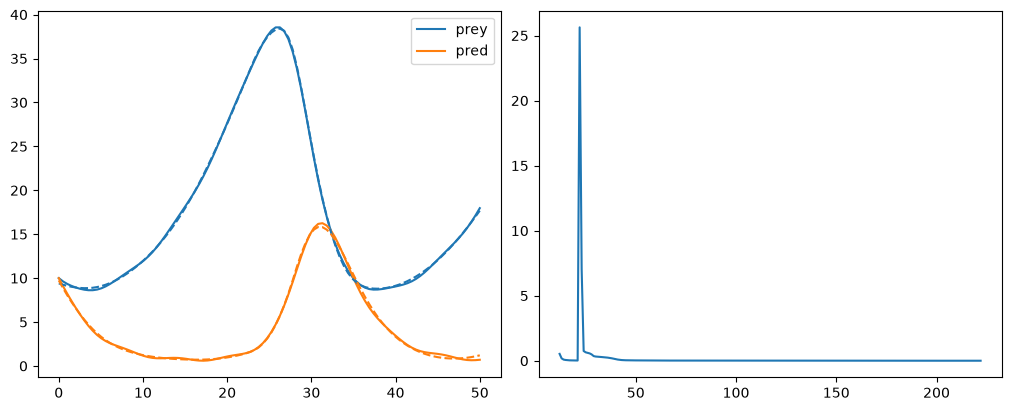

The network, width and training budget are the same as for the `Node`, plus two hidden dimensions, and the fit is now close.

## Augmented UDEs: `AugUde`

`AugUde` combines a mechanistic `Ode` with an `Anode`, in the same way that `Ude` combines it with a `Node`. With \(d = \text{Anode}(t, z, \text{args})\) on the latent state \(z = (y, h)\):

\[ \begin{aligned} \frac{dy}{dt} &= \text{op}\big(\text{ODE}(t, y, \text{args}),\ d_{[:n_{obs}]}\big) \\ \frac{dh}{dt} &= d_{[n_{obs}:]} \end{aligned} \]

The mechanistic model only sees the observed slice \(y = z_{[:n_{obs}]}\), so the hidden dimensions reach the observed dynamics only through the neural correction. This follows the hybrid-modelling literature. Augmented NODEs define the hidden dimensions for the neural model. Physics-plus-correction hybrids such as APHYNITY (Yin et al., 2021) keep the mechanistic term on the physical state. In latent hybridisation (Qian et al., 2021), the expert ODE runs on its own variables and drives the ML variables, not the other way round. If unobserved variables have known mechanisms, add them to the `Ode` itself rather than as hidden dimensions.

Because the mechanistic part reads \(z_{[:n_{obs}]}\), the latent mapper has to keep the observation there:

- `HardLatentMapper` is the interpretable choice: the decoded observations are exactly the state the mechanistic model sees.
- `MixedLatentMapper` and `TrainableZ0LatentMapper` anneal towards it.
- `SoftLatentMapper` is allowed, but its learned decode means the reported observations differ from what the ODE acts on.
- `FullLatentMapper` doesn't keep the observation and is rejected.

```python
aug_ude, aug_ude_losses = fit(
    AugUde(
        ode=lv,
        nn=Anode(
            variable_names=lv.variable_names,
            n_hidden=2,
            width=8,
            depth=3,
            key=jax.random.PRNGKey(42),
            latent_mapper=HardLatentMapper,
        ),
        op="+",
    )
)
plot_fit(aug_ude, aug_ude_losses)
```

aug_ude, aug_ude_losses = fit( AugUde( ode=lv, nn=Anode( variable_names=lv.variable_names, n_hidden=2, width=8, depth=3, key=jax.random.PRNGKey(42), latent_mapper=HardLatentMapper, ), op="+", ) ) plot_fit(aug_ude, aug_ude_losses)

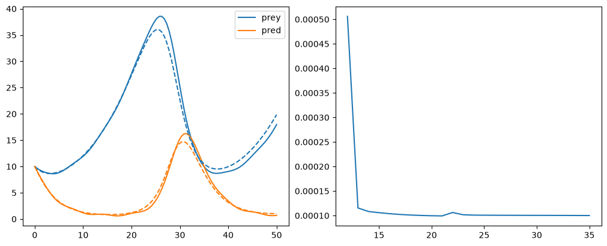

On this small example, `AugUde` reaches `train`'s default target loss early and fits about as well as the plain `Ude` above. The hidden dimensions earn their keep when the correction depends on something the observations don't contain, such as an unobserved species or an internal clock.

## Flux-based variants

Every model above has a flux-based counterpart for models built with reactions and stoichiometry. They combine the mechanistic and neural *fluxes*, then map them through the mechanistic stoichiometry `nv`:

| State-based | Flux-based | Neural part |
| --- | --- | --- |
| `Ode` | `FluxOde` | none |
| `Node` | `FluxNode` | flux MLP |
| `Ude` | `FluxUde` | `FluxNode` |
| `Anode` | `FluxAnode` | flux + Markov MLP |
| `AugUde` | `FluxAugUde` | `FluxAnode` |

In `FluxAnode` and `FluxAugUde` the hidden dimensions can't go through `nv`, which only maps onto the observed variables. Their dynamics come from a separate *Markov* MLP:

\[ \begin{aligned} v &= \text{op}\big(\text{fluxes}_{\text{ODE}}(t, y, \text{args}),\ \text{fluxes}_{\text{NN}}(t, z, \text{args})\big) \\ \frac{dy}{dt} &= N v \\ \frac{dh}{dt} &= \text{Markov}(z, \text{args}) \end{aligned} \]

`FluxNode.from_flux_ode` and `FluxAnode.from_flux_ode` build the neural part with the mechanistic model's variable names, flux names, stoichiometry and readouts. Simulations of `FluxUde`/`FluxAugUde` report the combined `fluxes`, and additionally the `ode_fluxes` and `nn_fluxes` that went into them. The model below is untrained; it only shows the construction.

```python
flux_lv = FluxOde.from_mxlpy(get_lotka_volterra())
flux_aug_ude = FluxAugUde(
    flux_ode=flux_lv,
    flux_nn=FluxAnode.from_flux_ode(
        flux_lv,
        n_hidden=2,
        key=jax.random.PRNGKey(42),
        latent_mapper=HardLatentMapper,
    ),
    op="+",
)
sim = flux_aug_ude.simulate_time_course(ts, y0, max_steps=8192)
sim.fluxes_df.head()
```

flux_lv = FluxOde.from_mxlpy(get_lotka_volterra()) flux_aug_ude = FluxAugUde( flux_ode=flux_lv, flux_nn=FluxAnode.from_flux_ode( flux_lv, n_hidden=2, key=jax.random.PRNGKey(42), latent_mapper=HardLatentMapper, ), op="+", ) sim = flux_aug_ude.simulate_time_course(ts, y0, max_steps=8192) sim.fluxes_df.head()

|  | prey_growth | predation | predator_death |
| --- | --- | --- | --- |
| 0.000000 | 0.967600 | 99.998016 | 4.005514 |
| 0.505050 | 0.923526 | 85.999863 | 3.610024 |
| 1.010101 | 0.890310 | 74.379524 | 3.240554 |
| 1.515152 | 0.866265 | 64.715080 | 2.900181 |
| 2.020202 | 0.850023 | 56.651234 | 2.589992 |